# ModelingToolkit Integration · Corleone.jl

## ModelingToolkit Integration

This is a quick intro based on [the lotka volterra fishing problem](https://mintoc.de/index.php?title=Lotka_Volterra_fishing_problem). It is similar to the classical fishing example, but we will use ModelingToolkit.jl to model it.

## Setup

We will use `Corleone` to define our optimal control problem.

```julia
using Corleone
using ModelingToolkit
using ModelingToolkit: t_nounits as t, D_nounits as D
using OrdinaryDiffEqTsit5
using ComponentArrays, ForwardDiff
using Optimization
using OptimizationMOI, Ipopt
using LuxCore, Random
using CairoMakie
```

We start by defining our system

```julia
@variables begin
    x(..) = 0.5, [tunable = false]
    y(..) = 0.7, [tunable = false]
    u(..) = 0.0, [bounds = (0.0, 1.0), input = true]
end
@constants begin
    c₁ = 0.4
    c₂ = 0.2
end
eqs = [
    D(x(t)) ~ x(t) - x(t) * y(t) - c₁ * u(t) * x(t)
    D(y(t)) ~ -y(t) + x(t) * y(t) - c₂ * u(t) * y(t)
]
costs = [
    Symbolics.Integral(t in (0.0, 12.0))(
        (x(t) - 1.0)^2 + (y(t) - 1.0)^2
    ),
]
@named lotka_volterra = System(eqs, t, costs = costs)

function plot_lotka(sol)
    f = Figure()
    ax = CairoMakie.Axis(f[1, 1])
    scatterlines!(ax, sol, vars = [1, 2, 3])
    f[1, 2] = Legend(f, ax, "States", framevisible = false)
    ax1 = CairoMakie.Axis(f[2, 1])
    stairs!(ax1, sol, vars = [4])
    f[2, 2] = Legend(f, ax1, "Controls", framevisible = false)
    return f
end
```

```
plot_lotka (generic function with 1 method)
```

## Single Shooting

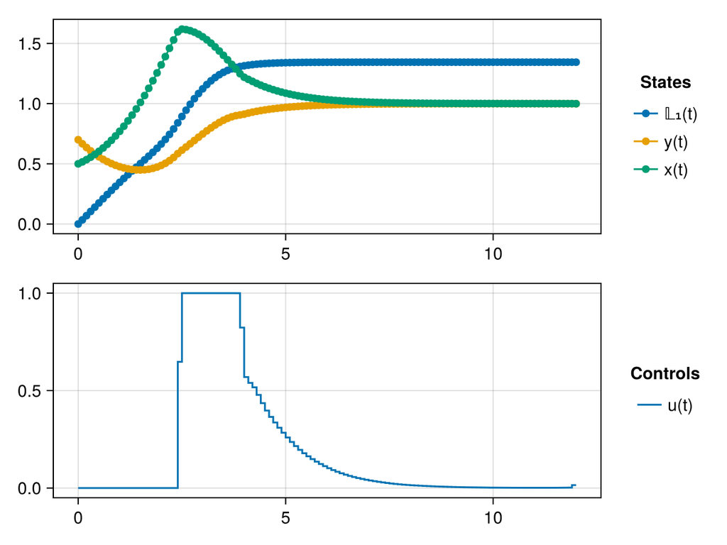

```julia
dynopt = CorleoneDynamicOptProblem(
    lotka_volterra, [],
    u(t) => 0.0:0.1:11.9,
    algorithm = Tsit5(),
)

optprob = OptimizationProblem(dynopt, AutoForwardDiff(), Val(:ComponentArrays))

sol = solve(
    optprob, Ipopt.Optimizer(), max_iter = 1000, tol = 5.0e-6,
    hessian_approximation = "limited-memory"
)


u_opt = ComponentVector(sol.u, optprob.f.f.ax)
opt_traj, _ = dynopt.layer(nothing, u_opt, LuxCore.initialstates(Random.default_rng(), dynopt.layer))

plot_lotka(opt_traj)
```

## Multiple Shooting

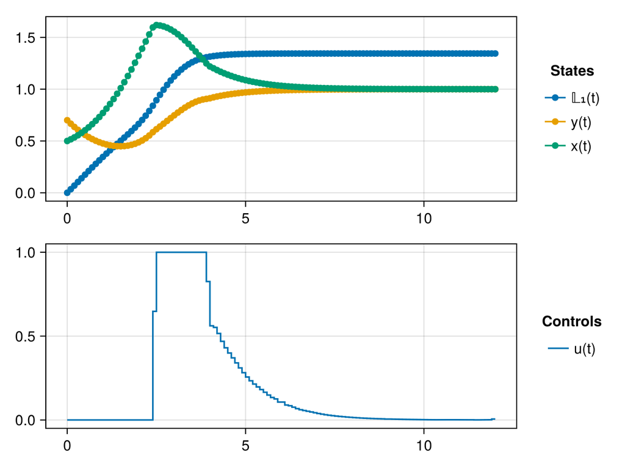

```julia
dynopt = CorleoneDynamicOptProblem(
    lotka_volterra, [],
    u(t) => 0.0:0.1:11.9,
    algorithm = Tsit5(),
    shooting = [0.0, 3.0, 6.0, 9.0]
)

optprob = OptimizationProblem(dynopt, AutoForwardDiff(), Val(:ComponentArrays))

sol = solve(
    optprob, Ipopt.Optimizer(), max_iter = 1000, tol = 5.0e-6,
    hessian_approximation = "limited-memory"
)

u_opt = ComponentVector(sol.u, optprob.f.f.ax)
opt_traj, _ = dynopt.layer(nothing, u_opt, LuxCore.initialstates(Random.default_rng(), dynopt.layer))

plot_lotka(opt_traj)
```

## Appendix

**This example was built using these direct dependencies,**

```julia
        using Pkg
        Pkg.status()
```

```
Status `~/_work/Corleone.jl/Corleone.jl/docs/Project.toml`
  [13f3f980] CairoMakie v0.15.13
  [b0b7db55] ComponentArrays v0.15.47
  [2751e0db] Corleone v0.0.7 `~/_work/Corleone.jl/Corleone.jl`
  [6590a4b1] CorleoneOED v0.0.8 `~/_work/Corleone.jl/Corleone.jl/lib/CorleoneOED`
  [e30172f5] Documenter v1.17.0
  [daee34ce] DocumenterCitations v1.5.0
  [d12716ef] DocumenterInterLinks v1.1.0
  [f6369f11] ForwardDiff v1.4.5
  [b6b21f68] Ipopt v1.15.0
  [682c06a0] JSON v1.7.1
  [2ddba703] Juniper v0.9.4
  [98b081ad] Literate v2.21.0
  [bb33d45b] LuxCore v1.5.3
  [961ee093] ModelingToolkit v11.40.0
  [d147904a] OptimalControlBenchmarks v0.0.3 `~/_work/Corleone.jl/Corleone.jl/lib/OptimalControlBenchmarks`
  [7f7a1694] Optimization v5.9.0
  [22f7324a] OptimizationLBFGSB v1.5.1
  [fd9f6733] OptimizationMOI v1.4.1
  [b1df2697] OrdinaryDiffEqTsit5 v2.1.4
  [2efcf032] SymbolicIndexingInterface v0.3.55
  [ddb6d928] YAML v0.4.16
  [9a3f8284] Random v1.11.0
```

**and using this machine and Julia version.**

```julia
        using InteractiveUtils
        InteractiveUtils.versioninfo()
```

```
Julia Version 1.12.7
Commit 6d172b025e4 (2026-08-15 08:05 UTC)
Build Info:
  Official https://julialang.org release
Platform Info:
  OS: Linux (x86_64-linux-gnu)
  CPU: 128 × AMD EPYC 9354 32-Core Processor
  WORD_SIZE: 64
  LLVM: libLLVM-18.1.7 (ORCJIT, znver4)
  GC: Built with stock GC
Threads: 1 default, 1 interactive, 1 GC (on 4 virtual cores)
Environment:
  JULIA_CPU_THREADS = 4
  JULIA_NUM_PRECOMPILE_TASKS = 4
```

**A more complete overview of all dependencies and their versions is also provided.**

```julia
        using Pkg
        Pkg.status(; mode = PKGMODE_MANIFEST)
```

[output not shown]

[output not shown]

*This page was generated using Literate.jl.*